# Los Grupos cristalográficos.

# Cmm

```python
icmm = Image.open('cmm.jpg')
```

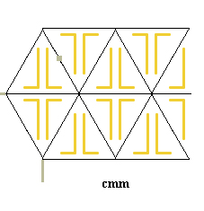

```python
icmm
```

Para generar el siguiente grupo, puesto que la región fundamental es un triangulo, debemos transformar nuestra imagen en un triangulo. Por tanto creamos la función triangulo.

```python
def triangulo(imag):
    mp=imag.load()
    imagaux=Image.new("RGBA",(imag.size[0],imag.size[1]),"white")
    mpaux=imagaux.load()
    for i in range(imag.size[0]):
        for j in range(imag.size[1]):
            if j>=(-2*imag.size[1]/imag.size[0])*i+imag.size[1] and j>=(2*imag.size[1]/imag.size[0])*i-imag.size[1]:
                mpaux[i,j]=mp[i,j]
            else:
                mpaux[i,j]=(255,255,255,0)
    return(imagaux)
```

[figure not shown]

```python
triangulo(au)
```

```python
def cmm(imag,rang):
    mp=imag.load()
    imagaux=triangulo(imag)
    mpaux=imagaux.load()
    im1=Image.new("RGBA",(imag.size[0]*2,imag.size[1]*2),"white")
    fin=Image.new("RGB",(imag.size[0]*2*rang,imag.size[1]*2*rang),"white")
    mpf=fin.load()
    mpim1=im1.load()
    imsim=Image.new("RGBA",(imag.size[0],imag.size[1]),"white")
    mpsim=imsim.load()
    s=Image.new("RGBA",(imag.size[0],imag.size[1]),"white")
    mps=s.load()
    for i in range(imag.size[0]):
        for j in range(imag.size[1]):
            mpsim[i,j]=mpaux[i,imag.size[1]-j-1]
    for i in range(imag.size[0]):
        for j in range(imag.size[1]):
            mps[i,j]=mpsim[i,imag.size[1]-j-1]
    im1.paste(imagaux, (0,0))
    im1.paste(imsim, (floor(imag.size[0]/2),0), imsim)
    im1.paste(imsim, (0,imag.size[1]))
    im1.paste(s, (floor(imag.size[0]/2),imag.size[1]),s)
    for i in range(-1,rang*2):
        for j in range(0,rang*2):
            fin.paste(im1, (i*imag.size[0],j*2*imag.size[1]),im1)
    return(fin)
```

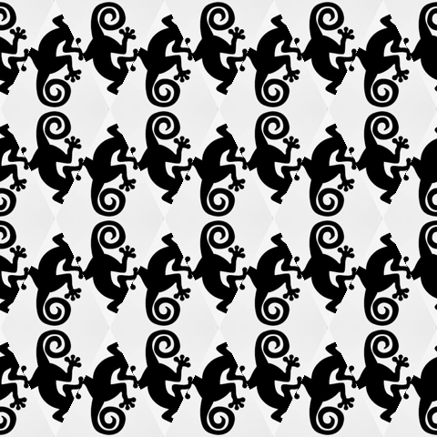

```python
cmm(au,2)
```

# P4m

```python
ip4m = Image.open('p4m.jpg')
```

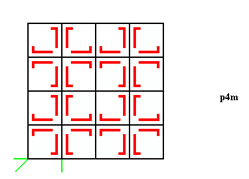

```python
ip4m
```

Para aplicar este grupo sobre una imagen, tenemos que adaptar la imagen a la región fundamental que es la siguiente:

```python
def divi1(imag):
    mp=imag.load()
    imagaux=Image.new("RGBA",(imag.size[0],imag.size[1]),"white")
    mpaux=imagaux.load()
    rot=imag.rotate(90)
    srot=SimV(imag)
    rot2=srot.rotate(90)
    mprot2=rot2.load()
    for i in range(imag.size[0]):
        for j in range(imag.size[1]):
            if j>=(imag.size[1]/imag.size[0])*i:
                mpaux[i,j]=mp[i,j]
            else:
                mpaux[i,j]=mprot2[i,j]
    return(imagaux)
```

[figure not shown]

```python
divi1(au)
```

```python
def p4mm(imag,rang):
    aux=divi1(imag)
    im1=p4(aux,rang)
    return(im1)
```

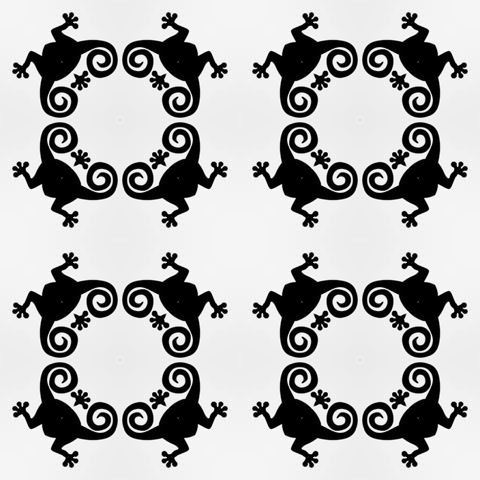

```python
p4mm(au,2)
```

# P4g

```python
ip4g = Image.open('p4g.jpg')
```

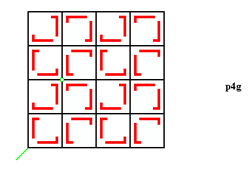

```python
ip4g
```

Adaptamos a la región fundamental.

```python
def divi2(imag):
    mp=imag.load()
    imagaux=Image.new("RGBA",(imag.size[0],imag.size[1]),"white")
    mpaux=imagaux.load()
    rot=imag.rotate(-90)
    srot=SimV(imag)
    rot2=srot.rotate(-90)
    mprot2=rot2.load()
    for i in range(imag.size[0]):
        for j in range(imag.size[1]):
            if j>=(-imag.size[1]/imag.size[0])*i+imag.size[1]:
                mpaux[i,j]=mp[i,j]
            else:
                #mpaux[i,j]=(255,255,255,0)
                mpaux[i,j]=mprot2[i,j]
    return(imagaux)
```

[figure not shown]

```python
divi2(au)
```

```python
def p4g(imag,rang):
    aux=divi2(imag)
    im1=p4(aux,rang)
    return(im1)
```

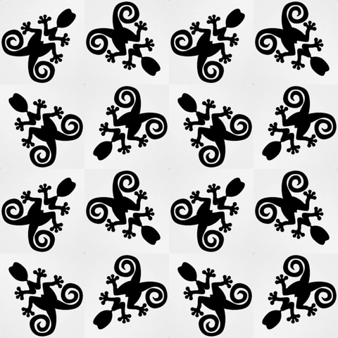

```python
p4g(au,2)
```

# P3

```python
ip3 = Image.open('p3.jpg')
```

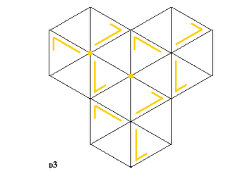

```python
ip3
```

Para los siguientes grupos necesitamos que la región fundamental sea un triangulo equilatero, por tanto definimos una función que nos transforme la imagen en un triangulo equilatero.

```python
def equilatero(imag):
    caja = (0, imag.size[1]-floor(math.sqrt(imag.size[1]**2-(imag.size[1]/2)**2)), imag.size[0], imag.size[1])
    modif = imag.crop(caja)
    tmod=triangulo(modif)
    return(tmod)
```

```python
equilatero(au)
```

[output not shown]

```python
def p3(imag,rang):
    mp=imag.load()
    imagaux=equilatero(imag)
    mpaux=imagaux.load()
    im1=Image.new("RGBA",(imagaux.size[0]*3,imagaux.size[1]*3),"white")
    fin=Image.new("RGB",(imagaux.size[0]*3*rang,imagaux.size[1]*3*rang),"white")
    mpf=fin.load()
    mpim1=im1.load()
    imsim=Image.new("RGBA",(imagaux.size[0],imagaux.size[1]),"white")
    mpsim=imsim.load()
    s=Image.new("RGBA",(imagaux.size[0],imagaux.size[1]),"white")
    mps=s.load()
    s2=Image.new("RGBA",(imagaux.size[0],imagaux.size[1]),"white")
    mps2=s2.load()
    for i in range(imagaux.size[0]):
        for j in range(imagaux.size[1]):
            mpsim[i,j]=mpaux[i,imagaux.size[1]-j-1]
    rc=imsim.rotate(-120, expand=1)
    caja=(rc.size[0]-imagaux.size[0],rc.size[1]-imagaux.size[1],rc.size[0],rc.size[1])
    rc2=rc.crop(caja)
    mprc2=rc2.load()
    rccc=imagaux.rotate(-120, expand=1)
    caja3=(0,0,imagaux.size[0],imagaux.size[1])
    rccc2=rccc.crop(caja3)
    mprccc2=rccc2.load()
    for i in range(imagaux.size[0]):
        for j in range(imagaux.size[1]):
            mps[i,j]=mprc2[i,imagaux.size[1]-j-1]
    for i in range(imagaux.size[0]):
        for j in range(imagaux.size[1]):
            mps2[i,j]=mprccc2[i,imagaux.size[1]-j-1]
    im1.paste(imagaux, (0,0))
    im1.paste(s, (floor(imagaux.size[0]/2),imagaux.size[1]),s)
    im1.paste(rccc2, (imagaux.size[0]-2,0),rccc2)
    for i in range(-2,rang*2):
        for j in range(-2,rang*2):
            fin.paste(im1, (i*3*imagaux.size[0],j*2*imagaux.size[1]),im1)
    #for i in range(-2,rang*2):
        #for j in range(-2,rang*2):
            #if i%2==0 and j%2==0:
                #fin.paste(im1, (i*imagaux.size[0],j*2*imagaux.size[1]+imagaux.size[1]),im1)
    return(im1)
```

[figure not shown]

```python
p3(au,2)
```

# P31m

```python
ip31m = Image.open('p31m.jpg')
```

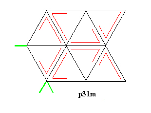

```python
ip31m
```

```python
def p31m(imag,rang):
    mp=imag.load()
    imagaux=equilatero(imag)
    mpaux=imagaux.load()
    im1=Image.new("RGBA",(imagaux.size[0]*3,imagaux.size[1]*3),"white")
    fin=Image.new("RGB",(imagaux.size[0]*3*rang,imagaux.size[1]*3*rang),"white")
    mpf=fin.load()
    mpim1=im1.load()
    imsim=Image.new("RGBA",(imagaux.size[0],imagaux.size[1]),"white")
    mpsim=imsim.load()
    s=Image.new("RGBA",(imagaux.size[0],imagaux.size[1]),"white")
    mps=s.load()
    s2=Image.new("RGBA",(imagaux.size[0],imagaux.size[1]),"white")
    mps2=s2.load()
    for i in range(imagaux.size[0]):
        for j in range(imagaux.size[1]):
            mpsim[i,j]=mpaux[i,imagaux.size[1]-j-1]
    rc=imsim.rotate(-120, expand=1)
    caja=(rc.size[0]-imagaux.size[0],rc.size[1]-imagaux.size[1],rc.size[0],rc.size[1])
    rc2=rc.crop(caja)
    mprc2=rc2.load()
    rccc=imagaux.rotate(-120, expand=1)
    caja3=(0,0,imagaux.size[0],imagaux.size[1])
    rccc2=rccc.crop(caja3)
    mprccc2=rccc2.load()
    for i in range(imagaux.size[0]):
        for j in range(imagaux.size[1]):
            mps[i,j]=mprc2[i,imagaux.size[1]-j-1]
    for i in range(imagaux.size[0]):
        for j in range(imagaux.size[1]):
            mps2[i,j]=mprccc2[i,imagaux.size[1]-j-1]
    im1.paste(imagaux, (0,0))
    im1.paste(rc2, (floor(imagaux.size[0]/2),0),rc2)
    im1.paste(imsim, (0,imagaux.size[1]))
    im1.paste(s, (floor(imagaux.size[0]/2),imagaux.size[1]),s)
    im1.paste(rccc2, (imagaux.size[0]-2,0),rccc2)
    im1.paste(s2,(imagaux.size[0]-2,imagaux.size[1]),s2)
    for i in range(-2,rang*2):
        for j in range(-2,rang*2):
            fin.paste(im1, (i*3*imagaux.size[0],j*2*imagaux.size[1]),im1)
    #for i in range(-2,rang*2):
        #for j in range(-2,rang*2):
            #if i%2==0 and j%2==0:
                #fin.paste(im1, (i*imagaux.size[0],j*2*imagaux.size[1]+imagaux.size[1]),im1)
    return(im1)
```

[figure not shown]

```python
p31m(au,2)
```

[figure not shown]

```python
au.rotate(45)
```